# Glue

## Water yield as function of bettle infestation in the Rocky mountains NP, Colorado (after Pugh and Gordon (2013)

### Glue test

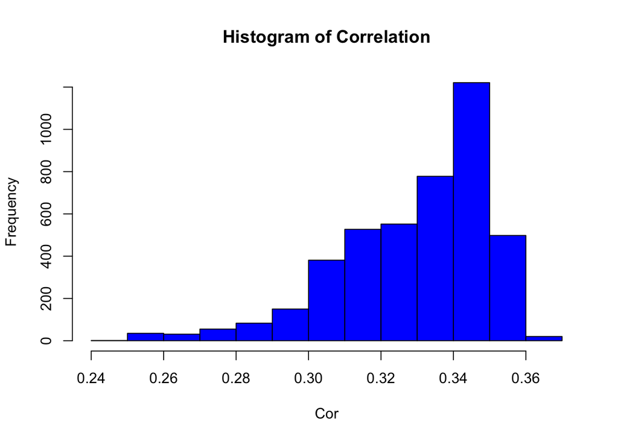

```r
# Compute the Pearson Correlation coefficient of modeled and observed records:
# tmp is an intermediate variable

tmp = apply(modQ.data, 2, cor, y=obsQ.data)
hist(tmp, main="Histogram of Correlation", xlab="Cor", col="blue")
```

Figure 1. Histogram of Correlation for observe Vs computed runoff

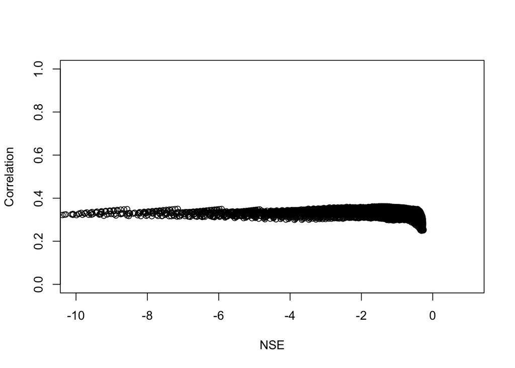

```r
# link this with parameters, the number of rows of parms should be the same as the size of tmp
# copy to a new data frame to store results
stats= parms
stats$cor = tmp

# Compute NSE
tmp = apply(modQ.data, 2, NSE, o=obsQ.data)
stats$nse = tmp

# Plot
plot(stats$nse, stats$cor, ylab="Correlation", xlab="NSE", ylim=c(0,1), xlim=c(-10,1))
```

Figure 2. NSE Vs correlation

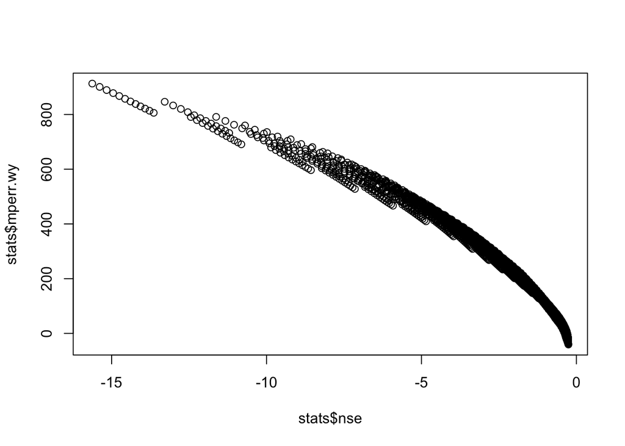

```r
# Another useful metric is found by taking the log of flows, if you have zero values in observed or modelled you will need to correct for this by adding a small amount
tmp = apply(log(modQ.data)+0.0001,2, NSE, o=log(obsQ.data)+0.0001)
stats$nselog = tmp
# Run test for annual flows (wy = water year)
modQ.data.wy = aggregate(modQ.data, by=list(dates.data$wy), sum)
obsQ.data.wy = aggregate(obsQ.data, by=list(dates.data$wy), sum)

# simple on the fly function
mperr = function(m,o) {
  err = m-o
  res = ifelse(o != 0, err/o, NA)
  return(mean(res)*100) }

# apply to our annual data
tmp = apply(modQ.data.wy[,(2:(nsims+1))],2, mperr, o=obsQ.data.wy[,2])
stats$mperr.wy = tmp

plot(stats$nse, stats$mperr.wy)
```

Figure 3. NSE Vs fly. Note that all NSE values are less than zero. negative nse values are generally poor - anything below zero is ‘random’.

To select “reasonable” model values we need an overall accuracy measure and then we need to decide an a threshold above which we consider the model reasonable. All indices are normalized between 0 and 1, with 1 being better

```r
# The original pmax(0.0,stats$nse) is zero (all original bellow zero), pmax(0.0, stats$nselog) is all infinity. So I used normalized correlation and together with the result of fly function:
stats$accuracy=pmax(0.0,(1-abs(stats$mperr/100)))*pmax(0.0, abs(stats$cor))
```

Table 1. Accuracy summary

```
##    Min. 1st Qu.  Median    Mean 3rd Qu.    Max.
## 0.00000 0.00000 0.00000 0.07231 0.15650 0.31780
```

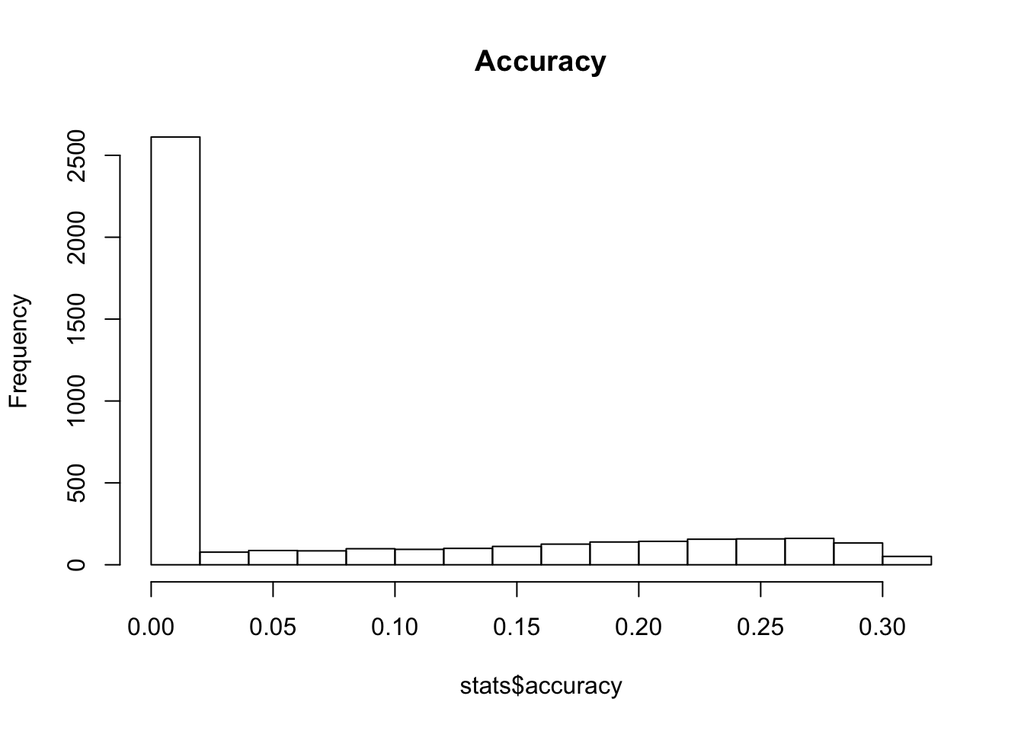

Figure 4. Histogram of accuracy for observe Vs computed runoff

Select behavioral or acceptable parameters sets. Use a 0.3 treshold.

```r
threshold = 0.3
stats.acc = subset(stats, stats$accuracy > threshold)

# Save the best parameters
setwd("/Users/baravni/Documents/Documents_master/master/R modelling/task1/Writing_Function/")
bestParms = stats.acc[1,1:3]
save(bestParms, file="EcohydrotoolsBAR3/data/bestParms.RData")
```

[figure not shown]

```r
# create a weight for each parameter set based on its relative accuracy
max_acc=max(stats.acc$accuracy)
min_acc=min(stats.acc$accuracy)
stats.acc$w_acc=(stats.acc$accuracy-min_acc)/(max_acc-min_acc)
sum_acc=sum(stats.acc$accuracy)
stats.acc$wt_acc=stats.acc$accuracy/sum_acc

Nacc = nrow(stats.acc)

# generate streamflow as weighted average of all acceptable parameter sets

accept.cols = stats.acc$row
accept.wts = stats.acc$wt_acc
aver.flow = apply(modQ.data[,accept.cols],1, weighted.mean, accept.wts)

# calculate upper and lower confidence bounds 95%
glue.res=apply(modQ.data[,accept.cols],1,"wtd.quantile",weights=accept.wts,prob=c(0.05,0.975),normwt=T)
glue.res=as.data.frame(t(glue.res))
colnames(glue.res)=c("low","high")

# plotting runoff for all acceptable parameter sets
tmp = stack(modQ.data[,accept.cols])
maxflow = max(tmp$values)
minflow = min(tmp$values)
```

Additional test was done to the summer and winter months separately due to the use of different models to snow and rain interception.

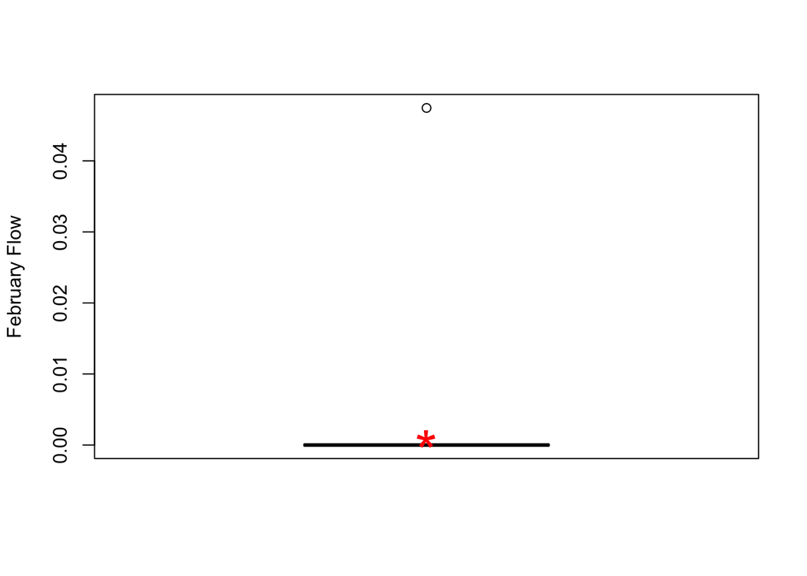

```r
# Move from days to months
modQ.mwy = aggregate(modQ.data[,1:nsims],by=list(dates.data$month, dates.data$wy), sum)
# do some re-arranging so month and year are at the end
modQ.mwy$wy = modQ.mwy$Group.2
modQ.mwy$month = modQ.mwy$Group.1
modQ.mwy = modQ.mwy[,3:(nsims+4)]

#same with obs
obsQ.mwy = aggregate(obsQ.data,by=list(dates.data$month, dates.data$wy), sum)
# do some re-arranging so month and year are at the end
obsQ.mwy$wy = obsQ.mwy$Group.2
obsQ.mwy$month = obsQ.mwy$Group.1
obsQ.mwy = obsQ.mwy[,3:4]


# February (snow interception model)
modQ.feb = subset(modQ.mwy, modQ.mwy$month==2)
# lets look at how monthly streamflow varies for each year across the range across all parameter

tmp = t(modQ.feb[,1:nsims])
tmp = c(tmp[,1],tmp[,2],tmp[,3],tmp[,4])
data.feb = data.frame(Runoff = tmp, Years = factor(rep(c("2012","2013","2014", "2015"), each=nsims)))
p5 = ggplot(data.feb, aes(x=Years, y=Runoff)) + geom_boxplot()
p5=p5+labs(y="Runoff (mm)", x="Years")

# now just our acceptable parameters
tmp = t(modQ.feb[,accept.cols])
tmp = c(tmp[,1],tmp[,2],tmp[,3],tmp[,4])
data.feb.acc = data.frame(Runoff = tmp, Years = factor(rep(c("2012","2013","2014", "2015"), each=length(accept.cols))))
p6 = ggplot(data.feb.acc, aes(x=Years, y=Runoff)) + geom_boxplot()
p6=p6+labs(y="Runoff (mm)", x="Years")


# uncertainty in mean February flow (overall whole simulation period)
# calculate mean february flow
modQ.feb.mean = apply(modQ.feb[,1:nsims], 2,mean)

# we use stack to put them all together
boxplot(modQ.feb.mean[accept.cols], ylab="February Flow")
# to find average
feb.wt.mean = weighted.mean(modQ.feb.mean[accept.cols],w=accept.wts)
points(feb.wt.mean, col="red", pch="*", cex=3)
```

Figure 6. uncertainty in mean February flow (overall whole simulation period). mean flow is in red star

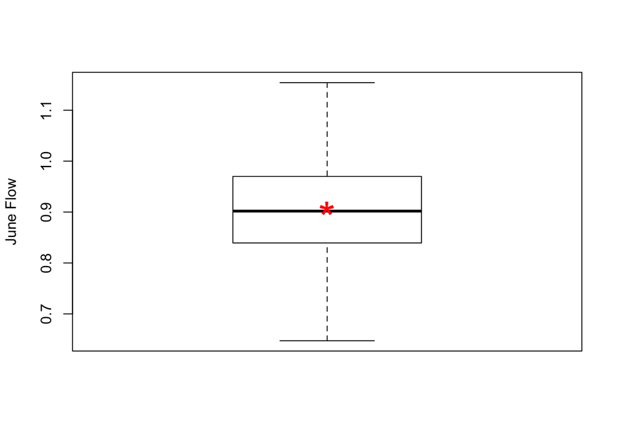

```r
# June Flow (rainfall interception model)
modQ.jun = subset(modQ.mwy, modQ.mwy$month==6)

tmp = t(modQ.jun[,1:nsims])
tmp = c(tmp[,1],tmp[,2],tmp[,3],tmp[,4])
data.jun = data.frame(Runoff = tmp, Years = factor(rep(c("2012","2013","2014", "2015"), each=nsims)))
p7 = ggplot(data.jun, aes(x=Years, y=Runoff)) + geom_boxplot()
p7=p7+labs(y="Runoff (mm)", x="Years")

# acceptable parameters only
tmp = t(modQ.jun[,accept.cols])
tmp = c(tmp[,1],tmp[,2],tmp[,3],tmp[,4])
data.jun.acc = data.frame(Runoff = tmp, Years = factor(rep(c("2012","2013","2014", "2015"), each=length(accept.cols))))
p8 = ggplot(data.jun.acc, aes(x=Years, y=Runoff)) + geom_boxplot()
p8=p8+labs(y="Runoff (mm)", x="Years")

#Uncertainty in mean June flow (overall whole simulation period)
# calculate mean June flow
modQ.jun.mean = apply(modQ.jun[,1:nsims], 2,mean)

boxplot(modQ.jun.mean[accept.cols], ylab="June Flow")
# to find average
jun.wt.mean = weighted.mean(modQ.jun.mean[accept.cols],w=accept.wts)
points(jun.wt.mean, col="red", pch="*", cex=3)
```

Figure 7. uncertainty in mean June flow (overall whole simulation period). mean flow is in red star

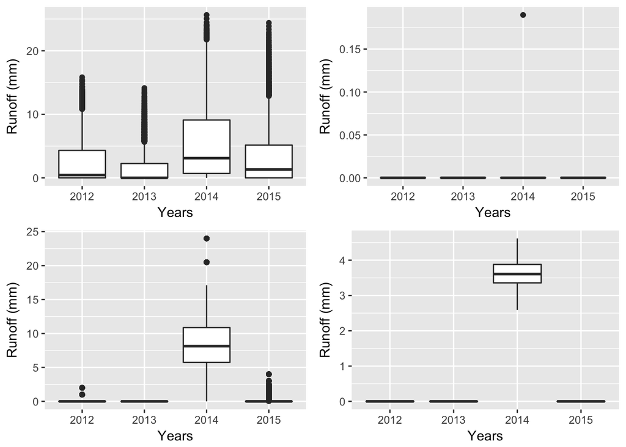

```r
# Arrange figure together
grid.arrange(p5,p6,p7,p8)
```

Figure 8. Monthly runoff varies for each year across the range across all parameters sets. Top left is for all parameters in February, top right is for acceptable parameters in February, bottom left is for all parameters in June and bottom right is for accaptible premeters in June.